# HW3

Author

Christine Raj

## Libraries

```r
library(ggplot2)
library(tidyverse)
library(tidytext)
library(dplyr)
library(readr)
library(data.table)
```

## Importing Data

```r
pubmed <- read_csv("https://raw.githubusercontent.com/USCbiostats/data-science-data/master/03_pubmed/pubmed.csv")
pubmed <- pubmed %>%
  select(abstract, term)

saveRDS(pubmed, file = "pubmed.rds")
pubmedrds <- readRDS("pubmed.rds")
head(pubmed)
```

```
# A tibble: 6 × 2
  abstract                                                                 term
  <chr>                                                                    <chr>
1 "Background and aims: Many patients with coronavirus disease 2019 (COVI… covid
2 "Introduction: Contradictory data have been reported on the incidence o… covid
3 "This article aims at collecting all information needed for dentists re… covid
4 "OBJECTIVE. The objective of our study was to determine the misdiagnosi… covid
5 "Background: Much of the focus regarding the global pandemic of coronav… covid
6 "The World Health Organization (WHO) has issued a warning that, althoug… covid
```

## Counting Tokenized Words by Term with and without Stop Words

```r
pubmedrds %>%
  unnest_tokens(token, term) %>%
  count(token, sort = TRUE) %>%
  top_n(20, n)
```

```
# A tibble: 7 × 2
  token            n
  <chr>        <int>
1 covid          981
2 cancer         787
3 prostate       787
4 preeclampsia   780
5 cystic         376
6 fibrosis       376
7 meningitis     317
```

```r
pubmedgroup <- pubmedrds %>% group_by(term)

abstractfreq <- pubmedgroup %>%
  unnest_tokens(token, abstract) %>%
  count(term, token, sort = TRUE)

abstractfreq %>%
  group_by(term) %>%
  top_n(5, n)
```

```
# A tibble: 25 × 3
# Groups:   term [5]
   term            token     n
   <chr>           <chr> <int>
 1 covid           the    9741
 2 covid           of     7668
 3 covid           covid  7275
 4 preeclampsia    the    7119
 5 covid           19     7035
 6 covid           and    6861
 7 preeclampsia    of     6837
 8 prostate cancer the    6100
 9 prostate cancer of     5682
10 preeclampsia    and    5255
# ℹ 15 more rows
```

```r
abstractfreqnostop <- pubmedgroup %>%
  unnest_tokens(token, abstract) %>%
  count(term, token, sort = TRUE) %>%
  anti_join(stop_words, by = c("token" = "word")) %>%
  anti_join(data.frame(token = as.character(0:9)), by = "token")

abstractfreqnostop %>%
  group_by(term) %>%
  top_n(5, n)
```

```
# A tibble: 25 × 3
# Groups:   term [5]
   term            token            n
   <chr>           <chr>        <int>
 1 covid           covid         7275
 2 covid           19            7035
 3 prostate cancer cancer        3840
 4 prostate cancer prostate      3832
 5 covid           patients      2293
 6 preeclampsia    pre           2038
 7 preeclampsia    eclampsia     2005
 8 preeclampsia    preeclampsia  1863
 9 preeclampsia    women         1196
10 preeclampsia    pregnancy      969
# ℹ 15 more rows
```

When we tokenize the words by term without eliminating stop words the largest tokenized words are stop words. There is a lot of words such as the, of, and and that are in the top words used in multiple different search terms. Even with stop words included covid and 19 are extremely common in these abstracts. Once stop words are taken out the most common words are the actual term words that are used to search for the abstracts. Other common words are patients and the diseases that are being looked up.

## Bigram Graph

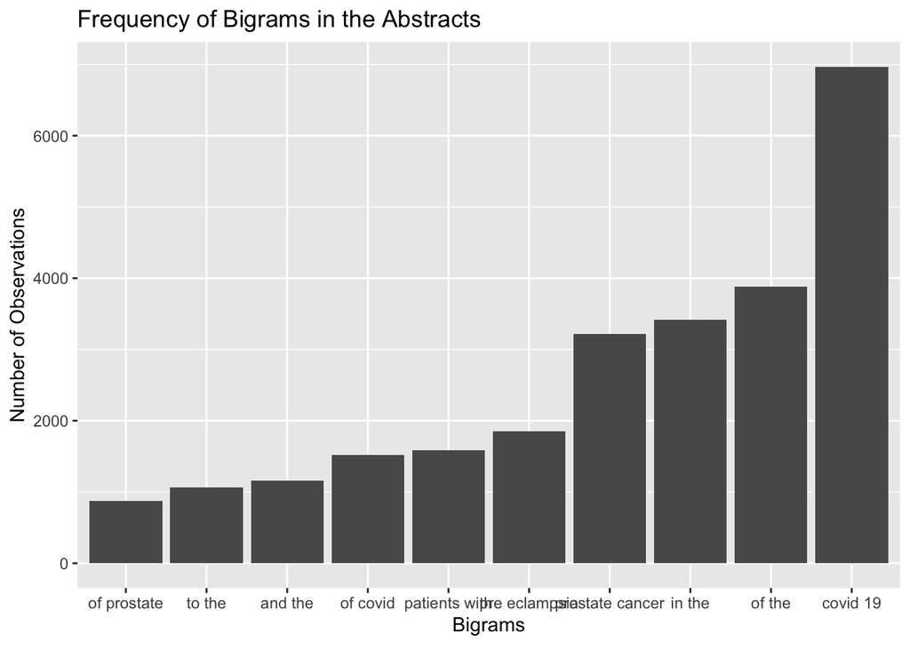

```r
bigramgraph <-
  pubmedrds %>%
  unnest_ngrams(bigram, abstract, n = 2) %>%
  count(bigram, sort = TRUE) %>%
  top_n(10, n)

bigramgraph %>%
  ggplot() +
  geom_bar(mapping = aes(x = reorder(bigram, n), y = n), stat = "identity") +
  labs(title = "Frequency of Bigrams in the Abstracts") +
  labs(x = expression("Bigrams"), y = "Number of Observations")
```

## TF-IDF

```r
allwords <- pubmedrds %>%
  unnest_tokens(word, abstract)

tf <- allwords %>%
  group_by(term, word) %>%
  count() %>%
  ungroup()

idf <- tf %>%
  group_by(word) %>%
  summarise(docfreq = n())

tfidfdata <- tf %>%
   left_join(idf, by = "word") %>%
  mutate(tfidf = n * log2(n_distinct(term) / docfreq))

tfidfdata %>%
  group_by(term) %>%
  top_n(5, tfidf)
```

```
# A tibble: 25 × 5
# Groups:   term [5]
   term            word            n docfreq  tfidf
   <chr>           <chr>       <int>   <int>  <dbl>
 1 covid           coronavirus   647       1  1502.
 2 covid           cov           334       1   776.
 3 covid           covid        7275       1 16892.
 4 covid           pandemic      800       1  1858.
 5 covid           sars          372       1   864.
 6 cystic fibrosis cf            625       2   826.
 7 cystic fibrosis cftr           86       1   200.
 8 cystic fibrosis cystic        862       3   635.
 9 cystic fibrosis fibrosis      867       3   639.
10 cystic fibrosis sweat          83       1   193.
# ℹ 15 more rows
```

The words with the highest TF-IDF values are somewhat similar to those seen in question 1. Still a lot of the words with the highest TF-IDF values are the disease that each term is looking at. One thing that is different from question 1 is that acronyms and shorthand form of words is more common than it had been in question 1. The 5 highest TF-IDF values for the search term covid is coronavirus, cov, covid, pandemic, and sars. The most common for the search term cystic fibrosis are cf, cftr, cystic, fibrosis, and sweat. The most common for the search term meningitis are csf, meninges, meningeal, meningitis, and pachymeningitis. The most common words for the search term preeclampsia are eclampsia, gestational, maternal, preeclampsia, and pregnancy. The most common words for the search term prostate cancer are prostate, androgen, psa, prostatectomy and castration.